# Clustering 2

Machine Learning

9 September 2020

```r
# install.packages("tidyr")
# install.packages("cluster")
# install.packages("factoextra")
# install.packages("sparcl")
# install.packages(teamcolors)
# install.packages("ggimage")
# install.packages("ggdark")
library(tidyr) # Load tidyr
library(cluster) # Load cluster
library(factoextra) # clustering algorithms & visualization
library(sparcl) # Sparse Clustering
library(teamcolors) # Load team colors
library(ggimage) # Load ggimage
library(ggdark) # Load ggdark
```

## Introduction

The data we are going to use for this analysis is college football summary data for 2024. The data contains statistics for each team and the plays they run at a season level. The data is broken down by play type and contains information on the EPA per play type, the frequency each play is run, and the proportion of times each play is chosen. We have data for overall and separated by down.

```r
load("cfb_2024_off.rda")
```

Lets view the data:

```r
head(off_dat) # View first few rows of data
```

```
##      teams Pass_freq_per_game Rush_freq_per_game Punt_freq_per_game
## 1  Alabama               28.2               35.5                4.1
## 4 Arkansas               33.7               32.9                2.9
## 6   Auburn               30.6               30.5                3.1
## 7    Miami               39.4               30.7                1.9
## 8  Florida               27.1               31.2                4.3
## 9  Georgia               36.7               28.4                3.5
##   Pass_avg_epa Rush_avg_epa Pass_prop_per_game Rush_prop_per_game
## 1    0.2638447   0.18929695          0.3705650          0.4664915
## 4    0.2029343   0.26374844          0.4249685          0.4148802
## 6    0.1722137   0.07667503          0.4226519          0.4212707
## 7    0.4377503   0.23462148          0.4775758          0.3721212
## 8    0.1654782   0.14119003          0.3838527          0.4419263
## 9    0.2694625   0.07996243          0.4735484          0.3664516
##   Pass_avg_epa_first_down Rush_avg_epa_first_down Pass_prop_per_game_first_down
```

[output cut: 41 more lines]

```r
tail(off_dat) # View last few rows of data
```

```
##            teams Pass_freq_per_game Rush_freq_per_game Punt_freq_per_game
## 175    Air Force               13.5           52.10000           4.200000
## 184 Oregon State               30.3           38.10000           3.100000
## 194 Northwestern               31.3           27.30000           5.200000
## 211         Army                8.0           54.11111           2.222222
## 216         Navy               14.0           43.20000           4.500000
## 238     Illinois               30.6           31.40000           3.600000
##     Pass_avg_epa Rush_avg_epa Pass_prop_per_game Rush_prop_per_game
## 175  -0.02281063  0.008603411          0.1767016          0.6819372
## 184  -0.07306498  0.204815576          0.3864796          0.4859694
## 194  -0.13098823  0.001539759          0.4408451          0.3845070
## 211   0.42820737  0.275469088          0.1116279          0.7550388
## 216   0.24627770  0.160125027          0.2020202          0.6233766
## 238   0.17489611  0.078577948          0.4151967          0.4260516
##     Pass_avg_epa_first_down Rush_avg_epa_first_down
```

[output cut: 41 more lines]

```r
dim(off_dat) # View dimensions of data
```

```
## [1] 67 20
```

```r
summary(off_dat) # Summarize offensive data
```

```
##     teams           Pass_freq_per_game Rush_freq_per_game Punt_freq_per_game
##  Length:67          Min.   : 8.0       Min.   :24.00      Min.   :1.900
##  Class :character   1st Qu.:28.2       1st Qu.:29.15      1st Qu.:3.250
##  Mode  :character   Median :31.6       Median :33.00      Median :3.800
##                     Mean   :31.5       Mean   :33.15      Mean   :3.766
##                     3rd Qu.:34.8       3rd Qu.:35.55      3rd Qu.:4.250
##                     Max.   :48.7       Max.   :54.11      Max.   :6.000
##   Pass_avg_epa      Rush_avg_epa      Pass_prop_per_game Rush_prop_per_game
##  Min.   :-0.1657   Min.   :-0.15242   Min.   :0.1116     Min.   :0.3117
##  1st Qu.: 0.0980   1st Qu.: 0.03586   1st Qu.:0.3810     1st Qu.:0.3844
##  Median : 0.1749   Median : 0.08023   Median :0.4152     Median :0.4279
##  Mean   : 0.1756   Mean   : 0.08877   Mean   :0.4098     Mean   :0.4340
##  3rd Qu.: 0.2543   3rd Qu.: 0.13342   3rd Qu.:0.4527     3rd Qu.:0.4677
##  Max.   : 0.4964   Max.   : 0.27547   Max.   :0.5540     Max.   :0.7550
##  Pass_avg_epa_first_down Rush_avg_epa_first_down Pass_prop_per_game_first_down
##  Min.   :-0.13068        Min.   :-0.22685        Min.   :0.07643
##  1st Qu.: 0.08799        1st Qu.:-0.05417        1st Qu.:0.31363
##  Median : 0.17169        Median : 0.01482        Median :0.35833
##  Mean   : 0.18718        Mean   : 0.01476        Mean   :0.35277
##  3rd Qu.: 0.27478        3rd Qu.: 0.07785        3rd Qu.:0.40515
##  Max.   : 0.71160        Max.   : 0.18946        Max.   :0.47884
##  Rush_prop_per_game_first_down Pass_avg_epa_second_down
##  Min.   :0.3464                Min.   :-0.3211
##  1st Qu.:0.4229                1st Qu.: 0.1247
##  Median :0.4660                Median : 0.1982
##  Mean   :0.4724                Mean   : 0.2153
##  3rd Qu.:0.5156                3rd Qu.: 0.3184
##  Max.   :0.7357                Max.   : 0.6265
##  Rush_avg_epa_second_down Pass_prop_per_game_second_down
##  Min.   :-0.21664         Min.   :0.1497
##  1st Qu.:-0.01477         1st Qu.:0.4245
##  Median : 0.06665         Median :0.4837
##  Mean   : 0.05673         Mean   :0.4779
##  3rd Qu.: 0.13019         3rd Qu.:0.5276
##  Max.   : 0.27832         Max.   :0.6892
##  Rush_prop_per_game_second_down Pass_avg_epa_third_down Rush_avg_epa_third_down
##  Min.   :0.3108                 Min.   :-0.32147        Min.   :-0.34227
##  1st Qu.:0.4558                 1st Qu.:-0.05267        1st Qu.: 0.05741
##  Median :0.5022                 Median : 0.09955        Median : 0.16361
##  Mean   :0.5075                 Mean   : 0.10927        Mean   : 0.19666
##  3rd Qu.:0.5653                 3rd Qu.: 0.26800        3rd Qu.: 0.34500
##  Max.   :0.8503                 Max.   : 0.97925        Max.   : 0.78296
##  Pass_prop_per_game_third_down Rush_prop_per_game_third_down
##  Min.   :0.1700                Min.   :0.1867
##  1st Qu.:0.5500                1st Qu.:0.3220
##  Median :0.6170                Median :0.3707
##  Mean   :0.6056                Mean   :0.3799
##  3rd Qu.:0.6692                3rd Qu.:0.4346
##  Max.   :0.8133                Max.   :0.8100
```

From this we see that we have no missing values in the data. The variables correspond to two different play types:

- Rushes
- Passes

## Initial Visualizations

Let’s visualize some of the EPA stats for each of the plays in the dataset:

```r
# Merge logos and data
plot_dat <- merge(off_dat, cfb_logos, by.x = "teams", by.y = "school")
```

First let’s look at the EPA per rush and rush frequency per game:

```r
# Create plot
g_1 <- ggplot(plot_dat, # Set dataset
              aes(x = Rush_freq_per_game, y = Rush_avg_epa)) + # Set aesthetics
  geom_point(alpha = 0.3) + # Set geom point
  geom_image(image = plot_dat$logos, asp = 16/9) + # Add logos
  labs(y = "Average EPA per Rush", # Add labels
       x = "Rush Frequency per Game",
       title = "EPA per Rush v Rush Frequency per Game",
       subtitle = "CFB - 2024 Season") +
  dark_theme_bw() + # Set theme
  theme( # Modify plot elements
    axis.text = element_text(size = 10), # Change Axis text size
    axis.title.x = element_text(size = 12), # Change x axis title size
    axis.title.y = element_text(size = 12), # Change y axis title size
    plot.title = element_text(size = 16), # Change plot title size
    plot.subtitle = element_text(size = 14), # Change plot subtitle size
    plot.caption = element_text(size = 10), # Change plot caption size
    panel.grid.major = element_blank(), # Remove grid
        panel.grid.minor = element_blank(), # Remove grid
        panel.border = element_blank(), # Remove grid
        panel.background = element_blank()) # Remove grid
```

```
## Inverted geom defaults of fill and color/colour.
## To change them back, use invert_geom_defaults().
```

[figure not shown]

```r
# Generate plot
g_1
```

```r
# Turn off dark mode
invert_geom_defaults()
```

Next let’s look at pass plays:

```r
# Create plot
g_2 <- ggplot(plot_dat, # Set dataset
              aes(x = Pass_freq_per_game, y = Pass_avg_epa)) + # Set aesthetics
  geom_point(alpha = 0.3) +  # Set geom point
  geom_image(image = plot_dat$logos, asp = 16/9) + # Add logos
  labs(y = "Average EPA per Pass", # Add labels
       x = "Pass Frequency per Game",
       title = "EPA per Pass v Pass Frequency per Game",
       subtitle = "CFB - 2024 Season") +
  dark_theme_bw() + # Set theme
  theme( # Modify plot elements
    axis.text = element_text(size = 10), # Change Axis text size
    axis.title.x = element_text(size = 12), # Change x axis title size
    axis.title.y = element_text(size = 12), # Change y axis title size
    plot.title = element_text(size = 16), # Change plot title size
    plot.subtitle = element_text(size = 14), # Change plot subtitle size
    plot.caption = element_text(size = 10), # Change plot caption size
    panel.grid.major = element_blank(), # Remove grid
        panel.grid.minor = element_blank(), # Remove grid
        panel.border = element_blank(), # Remove grid
        panel.background = element_blank()) # Remove grid
```

```
## Inverted geom defaults of fill and color/colour.
## To change them back, use invert_geom_defaults().
```

[figure not shown]

```r
# Generate plot
g_2
```

```r
# Turn off dark mode
invert_geom_defaults()
```

Now let’s just look at EPA earned on passes and rushes:

```r
# Create plot
g_3 <- ggplot(plot_dat, # Set dataset
              aes(x = Rush_avg_epa, y = Pass_avg_epa)) + # Set aesthetics
  geom_point(alpha = 0.3) +  # Set geom point
  geom_image(image = plot_dat$logos, asp = 16/9) + # Add logos
  labs(y = "Average EPA per Pass", # Add labels
       x = "Average EPA per Rush",
       title = "EPA per Pass v EPA per Rush",
       subtitle = "CFB - 2024 Season") +
  dark_theme_bw() + # Set theme
  theme( # Modify plot elements
     axis.text = element_text(size = 10), # Change Axis text size
    axis.title.x = element_text(size = 12), # Change x axis title size
    axis.title.y = element_text(size = 12), # Change y axis title size
    plot.title = element_text(size = 16), # Change plot title size
    plot.subtitle = element_text(size = 14), # Change plot subtitle size
    plot.caption = element_text(size = 10), # Change plot caption size
    panel.grid.major = element_blank(), # Remove grid
        panel.grid.minor = element_blank(), # Remove grid
        panel.border = element_blank(), # Remove grid
        panel.background = element_blank())
```

```
## Inverted geom defaults of fill and color/colour.
## To change them back, use invert_geom_defaults().
```

[figure not shown]

```r
# Generate plot
g_3
```

```r
# Turn off dark mode
invert_geom_defaults()
```

Now let’s just look at first down plays:

```r
# Create plot
g_4 <- ggplot(plot_dat, # Set dataset
              aes(x = Rush_avg_epa_first_down, y = Pass_avg_epa_first_down)) + # Set aesthetics
  geom_point(alpha = 0.3) +  # Set geom point
  geom_image(image = plot_dat$logos, asp = 16/9) + # Add logos
  labs(y = "Average EPA per Pass", # Add labels
       x = "Average EPA per Rush",
       title = "EPA per Pass v EPA per Rush - First Down",
       subtitle = "CFB - 2024 Season") +
  dark_theme_bw() + # Set theme
  theme( # Modify plot elements
     axis.text = element_text(size = 10), # Change Axis text size
    axis.title.x = element_text(size = 12), # Change x axis title size
    axis.title.y = element_text(size = 12), # Change y axis title size
    plot.title = element_text(size = 16), # Change plot title size
    plot.subtitle = element_text(size = 14), # Change plot subtitle size
    plot.caption = element_text(size = 10), # Change plot caption size
    panel.grid.major = element_blank(), # Remove grid
        panel.grid.minor = element_blank(), # Remove grid
        panel.border = element_blank(), # Remove grid
        panel.background = element_blank())
```

```
## Inverted geom defaults of fill and color/colour.
## To change them back, use invert_geom_defaults().
```

[figure not shown]

```r
# Generate plot
g_4
```

```r
# Turn off dark mode
invert_geom_defaults()
```

## Clustering Preparation

Note that the values for the frequency per game, EPA per game and proportion per game are all on quite different scales. To ensure that our clustering algorithm pays equal attention to all of our variables we will scale the data in advance. We can do this running the `scale()` command. As the team names are in the data and are a character vector we will leave them out of the scaling and then add them back to our dataset:

```r
# Scale offensive data
off_dat_2 <- scale(off_dat[,2:20])
# Add teams back to data frame
off_dat <- cbind.data.frame(off_dat$teams, off_dat_2)
# Fix name of team column
names(off_dat)[1] <- "teams"
```

We are now ready to cluster our data.

## Initial Clustering

For our initial clustering lets try to fit four clusters to the data. To run K-means on our data we use the `kmeans()` function. The parameters we need to set for the K-means algorithm are:

- x - The data we want the algorithm to cluster
- centers - The number of clusters to generate.
- itermax - The number of iterations to let k-means perform
- nstart - The number of starts to try for K-means. Remember K-means may not converge to the optimal solution from a single start point. Therefore we may want to try multiple start points.

```r
set.seed(12345) # Set seed for reproducibility
fit_1 <- kmeans(x = off_dat[,2:20], # Set data as explantory variables
                centers = 4,  # Set number of clusters
                nstart = 25, # Set number of starts
                iter.max = 100 ) # Set maximum number of iterations to use
```

The results of our clustering is stored in `fit_1`. We can extract the clusters and center values for this as follows:

```r
# Extract clusters
clusters_1 <- fit_1$cluster
# Extract centers
centers_1 <- fit_1$centers
```

Lets first check how many samples have ended up in each cluster:

```r
# Check samples per cluster
summary(as.factor(clusters_1))
```

```
##  1  2  3  4
## 32 18  3 14
```

```r
# Check teams in cluster 1
cat("Cluster 1 teams:\n")
```

```
## Cluster 1 teams:
```

```r
off_dat$teams[clusters_1 == 1]
```

```
##  [1] "Alabama"           "Arkansas"          "Auburn"
##  [4] "Florida"           "Kentucky"          "Ole Miss"
##  [7] "Mississippi State" "South Carolina"    "Tennessee"
## [10] "Notre Dame"        "Texas A&M"         "Virginia Tech"
## [13] "Vanderbilt"        "North Carolina"    "Indiana"
## [16] "Nebraska"          "Ohio State"        "Oregon"
## [19] "Penn State"        "Rutgers"           "Iowa State"
## [22] "BYU"               "Georgia Tech"      "Boston College"
## [25] "Louisiana"         "Kansas"            "Arizona State"
## [28] "Baylor"            "Kansas State"      "Washington State"
## [31] "Oregon State"      "Illinois"
```

```r
# Check teams in cluster 2
cat("Cluster 2 teams:\n")
```

```
## Cluster 2 teams:
```

```r
off_dat$teams[clusters_1 == 2]
```

```
##  [1] "Miami"          "Georgia"        "Clemson"        "Texas"
##  [5] "USC"            "Minnesota"      "Maryland"       "UCLA"
##  [9] "Washington"     "Louisville"     "Colorado"       "Oklahoma State"
## [13] "NC State"       "TCU"            "Syracuse"       "Pittsburgh"
## [17] "Arizona"        "Texas Tech"
```

```r
# Check teams in cluster 3
cat("Cluster 3 teams:\n")
```

```
## Cluster 3 teams:
```

```r
off_dat$teams[clusters_1 == 3]
```

```
## [1] "Air Force" "Army"      "Navy"
```

```r
# Check teams in cluster 4
cat("Cluster 4 teams:\n")
```

```
## Cluster 4 teams:
```

```r
off_dat$teams[clusters_1 == 4]
```

```
##  [1] "Missouri"         "Oklahoma"         "Michigan"         "Michigan State"
##  [5] "Wisconsin"        "Wake Forest"      "Duke"             "Virginia"
##  [9] "Purdue"           "Stanford"         "Florida State"    "Utah"
## [13] "New Mexico State" "Northwestern"
```

Lets check how the center values for each of the clusters compare to each other. To make this interpret-able lets just use the overall game level values:

```r
# Create vector of clusters
cluster <- c(1: 4)
# Extract centers
center_df <- data.frame(cluster, centers_1)

# Reshape the data
center_reshape <- gather(center_df, features, values, Pass_freq_per_game:Rush_prop_per_game_third_down)
# View first few rows
head(center_reshape)
```

```
##   cluster           features        values
## 1       1 Pass_freq_per_game -0.3007969970
## 2       2 Pass_freq_per_game  1.0379143335
## 3       3 Pass_freq_per_game -3.0218608441
## 4       4 Pass_freq_per_game  0.0006163167
## 5       1 Rush_freq_per_game  0.3401972987
## 6       2 Rush_freq_per_game -0.8855210489
```

```r
# Create plot
g_heat_1 <- ggplot(data = center_reshape, # Set dataset
                   aes(x = features, y = cluster, fill = values)) + # Set aesthetics
  scale_y_continuous(breaks = seq(1, 4, by = 1)) + # Set y axis breaks
  geom_tile() + # Geom tile for heatmap
  coord_equal() +  # Make scale the same for both axis
  theme_set(theme_bw(base_size = 22) ) + # Set theme
  scale_fill_gradient2(low = "blue", # Choose low color
                       mid = "white", # Choose mid color
                       high = "red", # Choose high color
                       midpoint =0, # Choose mid point
                       space = "Lab",
                       na.value ="grey", # Choose NA value
                       guide = "colourbar", # Set color bar
                       aesthetics = "fill") + # Select aesthetics to apply
  coord_flip() # Rotate plot to view names clearly
```

[output not shown]

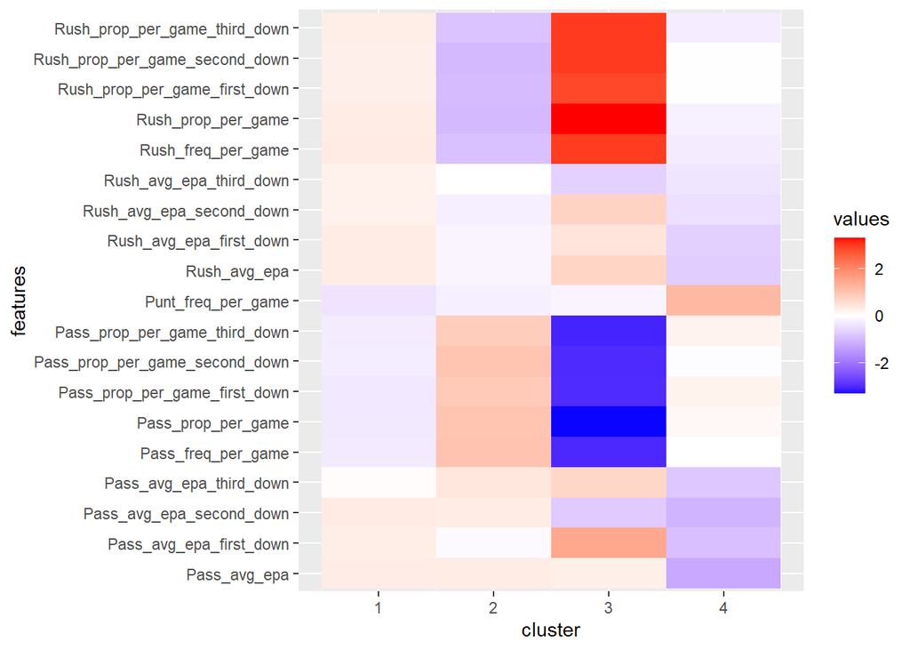

```r
# Generate plot
g_heat_1
```

### Calculate cluster number

Perhaps four is not the optimal cluster number for this dataset. Lets try a few different cluster values and view the error for each different number. Remember that the error will always decrease as we add more clusters so that we are looking for the point where the rate of improvement in performance starts to decrease.Ideally this plot will look like:

[figure not shown]

Ideal Elbow Plot

I have found that in reality a plot this clear is rarely found and it often be best to choose the number of clusters based on the needs of the analysis. Let’s create it anyway and see what it looks like for this dataset:

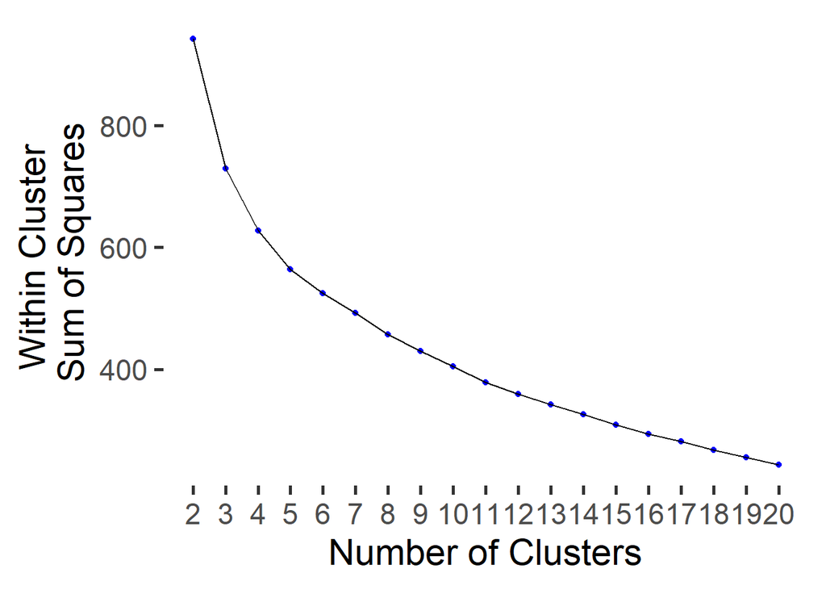

```r
# Create function to try different cluster numbers
kmean_withinss <- function(k) {
  cluster <- kmeans( x = off_dat[,2:20],  # Set data to use
                    centers = k,  # Set number of clusters as k, changes with input into function
                    nstart = 25, # Set number of starts
                    iter.max = 100) # Set max number of iterations
  return (cluster$tot.withinss) # Return cluster error/within cluster sum of squares
}


# Set maximum cluster number
max_k <-20
# Run algorithm over a range of cluster numbers
wss <- sapply(2:max_k, kmean_withinss)


# Create a data frame to plot the graph
elbow <-data.frame(2:max_k, wss)

# Plot the graph with ggplot
g_e1 <- ggplot(elbow, # Set dataset
              aes(x = X2.max_k, y = wss)) + # Set aesthetics
  theme_set(theme_bw(base_size = 22) ) + # Set theme
  geom_point(color = "blue") + # Set geom point for scatter
  geom_line() + # Geom line for a line between points
  scale_x_continuous(breaks = seq(1, 20, by = 1)) + # Set breaks for x-axis
  labs(x = "Number of Clusters", y="Within Cluster \nSum of Squares") + # Set labels
  theme(panel.grid.major = element_blank(), # Turn of the background grid
        panel.grid.minor = element_blank(),
        panel.border = element_blank(),
        panel.background = element_blank())
# Generate plot
g_e1
```

This is a pretty tough plot to decide what cluster number to choose. Let’s try 6 clusters and see what results we get:

```r
set.seed(12345) # Set seed for reproducibility
fit_2 <- kmeans(x = off_dat[2:20], # Set data as explanatory variables
                centers = 6,  # Set number of clusters
                nstart = 25, # Set number of starts
                iter.max = 100 ) # Set maximum number of iterations to use

# Extract clusters
clusters_2 <- fit_2$cluster
# Extract centers
centers_2 <- fit_2$centers
```

```r
# Check samples per cluster
summary(as.factor(clusters_2))
```

```
##  1  2  3  4  5  6
## 12  2 11 25 16  1
```

Lets check the teams in each cluster:

```r
# Check teams in cluster 1
cat("Cluster 1 teams:\n")
```

```
## Cluster 1 teams:
```

```r
off_dat$teams[clusters_2 == 1]
```

```
##  [1] "Oklahoma"       "Minnesota"      "Michigan State" "Wisconsin"
##  [5] "Wake Forest"    "Duke"           "Virginia"       "Purdue"
##  [9] "Stanford"       "Florida State"  "Utah"           "Northwestern"
```

```r
# Check teams in cluster 2
cat("Cluster 2 teams:\n")
```

```
## Cluster 2 teams:
```

```r
off_dat$teams[clusters_2 == 2]
```

```
## [1] "Air Force" "Navy"
```

```r
# Check teams in cluster 3
cat("Cluster 3 teams:\n")
```

```
## Cluster 3 teams:
```

```r
off_dat$teams[clusters_2 == 3]
```

```
##  [1] "Alabama"          "Arkansas"         "Miami"            "Ole Miss"
##  [5] "Indiana"          "Ohio State"       "Oregon"           "Penn State"
##  [9] "Louisiana"        "Kansas"           "Washington State"
```

```r
# Check teams in cluster 4
cat("Cluster 4 teams:\n")
```

```
## Cluster 4 teams:
```

```r
off_dat$teams[clusters_2 == 4]
```

```
##  [1] "Auburn"            "Florida"           "Kentucky"
##  [4] "Mississippi State" "Missouri"          "South Carolina"
##  [7] "Tennessee"         "Notre Dame"        "Texas A&M"
## [10] "Virginia Tech"     "Vanderbilt"        "North Carolina"
## [13] "Michigan"          "Nebraska"          "Rutgers"
## [16] "Iowa State"        "BYU"               "Georgia Tech"
## [19] "Boston College"    "Arizona State"     "Baylor"
## [22] "Kansas State"      "New Mexico State"  "Oregon State"
## [25] "Illinois"
```

```r
# Check teams in cluster 5
cat("Cluster 5 teams:\n")
```

```
## Cluster 5 teams:
```

```r
off_dat$teams[clusters_2 == 5]
```

```
##  [1] "Georgia"        "Clemson"        "Texas"          "USC"
##  [5] "Maryland"       "UCLA"           "Washington"     "Louisville"
##  [9] "Colorado"       "Oklahoma State" "NC State"       "TCU"
## [13] "Syracuse"       "Pittsburgh"     "Arizona"        "Texas Tech"
```

```r
# Check teams in cluster 6
cat("Cluster 6 teams:\n")
```

```
## Cluster 6 teams:
```

```r
off_dat$teams[clusters_2 == 6]
```

```
## [1] "Army"
```

Lets check the quality of our clustering solution using a silhouette plot:

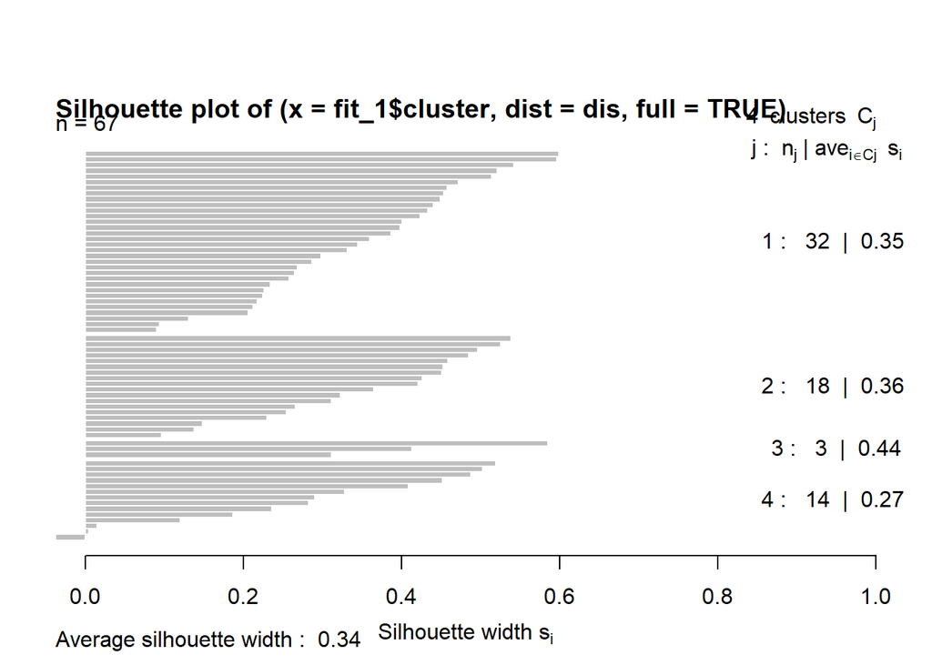

```r
# Calculate distance between samples
dis = dist(off_dat[2:20])^2
# Set plotting parameters to view plot
op <- par(mfrow= c(1,1), oma= c(0,0, 3, 0),
          mgp= c(1.6,.8,0), mar= .1+c(4,2,2,2))
# Create silhouette for k=4
sil = silhouette (fit_1$cluster , # Set clustering
                  dis, # Set distance
                  full = TRUE) # Generate silhouette for all samples
# Generate silhouette plot
plot(sil)
```

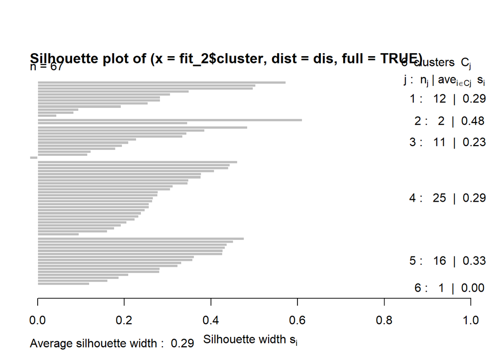

```r
# Create silhouette plot for k=6
sil = silhouette (fit_2$cluster , # Set clustering
                  dis, # Set distance
                  full = TRUE) # Generate for all samples
# Generate plot
plot(sil)
```

## Checking Clustering Quality

### Is my clustering okay

The first question we want to ask when checking clustering is to examine if we have a good clustering solution. This is not a rigorous process as there is no ground ‘truth’ to check our result against. We can analyse our clustering solution using:

- Visual Inspection
- Clustering Cardinality - Number of samples in each cluster
- Clustering Magnitude - Sum of distances of points to cluster center

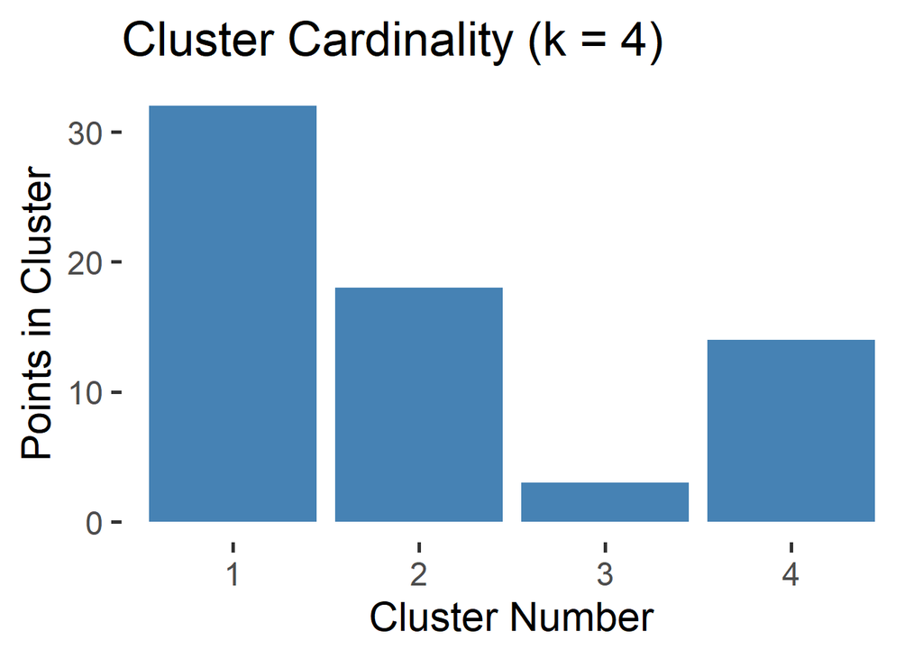

```r
plot_clust_cardinality <- cbind.data.frame(clusters_1, clusters_2) # Join clusters with  k =4 and k=6

names(plot_clust_cardinality) <- c("k_4", "k_6") # Set names

# Create bar plots
g_2 <- ggplot(plot_clust_cardinality, aes( x = factor(k_4))) + # Set x as cluster values
  geom_bar(stat = "count", fill = "steelblue") + # Use geom_bar with stat = "count" to count observations
    labs(x = "Cluster Number", y="Points in Cluster", # Set labels
         title = "Cluster Cardinality (k = 4)") +
  theme(panel.grid.major = element_blank(), # Turn of the background grid
        panel.grid.minor = element_blank(),
        panel.border = element_blank(),
        panel.background = element_blank())


g_3 <- ggplot(plot_clust_cardinality, aes( x = factor(k_6))) + # Set x as cluster values
  geom_bar(stat = "count", fill = "steelblue") + # Use geom_bar with stat = "count" to count observations
    labs(x = "Cluster Number", y="Points in Cluster", # Set labels
         title = "Cluster Cardinality (k = 6)") +
  theme(panel.grid.major = element_blank(), # Turn of the background grid
        panel.grid.minor = element_blank(),
        panel.border = element_blank(),
        panel.background = element_blank())

# Generate bar plots
g_2
```

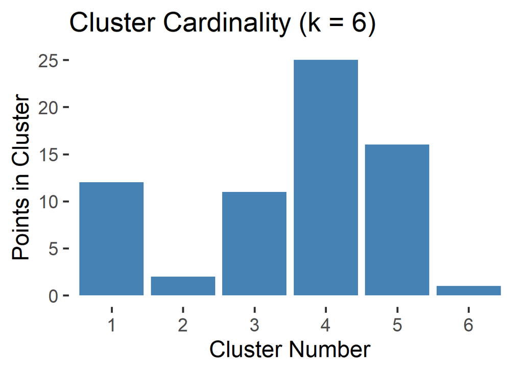

```r
g_3
```

Next we want to visualize the within cluster sum of squares for each cluster to see how good a fit each of the clusters was fit. This is also called cluster magnitude.

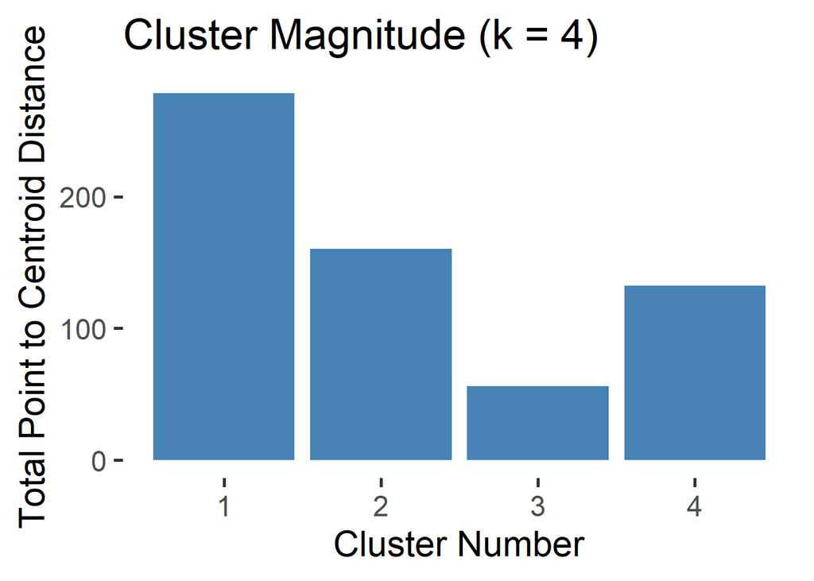

```r
k_4_mag <- cbind.data.frame(c(1:4), fit_1$withinss) # Extract within cluster sum of squares

names(k_4_mag) <- c("cluster", "withinss") # Fix names for plot data


# Create bar plot
g_4 <- ggplot(k_4_mag, aes(x = cluster, y = withinss)) + # Set x as cluster, y as withinss
  geom_bar(stat = "identity", fill = "steelblue") + # Use geom bar and stat = "identity" to plot values directly
   labs(x = "Cluster Number", y="Total Point to Centroid Distance", # Set labels
         title = "Cluster Magnitude (k = 4)") +
  theme(panel.grid.major = element_blank(), # Turn of the background grid
        panel.grid.minor = element_blank(),
        panel.border = element_blank(),
        panel.background = element_blank())

k_6_mag <- cbind.data.frame(c(1:6), fit_2$withinss) # Extract within cluster sum of squares
names(k_6_mag) <- c("cluster", "withinss") # Fix names for plot data

# Create bar plot
g_5 <- ggplot(k_6_mag, aes(x = cluster, y = withinss)) +  # Set x as cluster, y as withinss
  geom_bar(stat = "identity", fill = "steelblue") + # Use geom bar and stat = "identity" to plot values directly
   labs(x = "Cluster Number", y="Total Point to Centroid Distance", # Set labels
         title = "Cluster Magnitude (k = 6)") +
  theme(panel.grid.major = element_blank(), # Turn of the background grid
        panel.grid.minor = element_blank(),
        panel.border = element_blank(),
        panel.background = element_blank())

# Generate plots
g_4
```

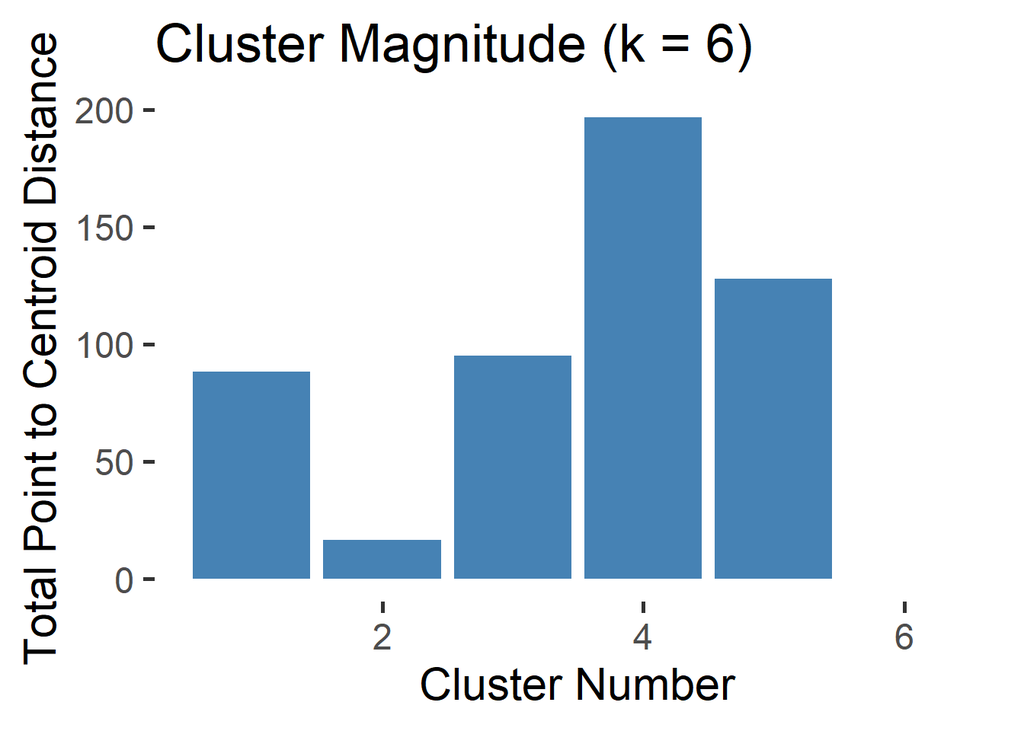

```r
g_5
```

From the above plots we can deduce that clusters with a higher number of samples are likely to have a higher within cluster sum of squares and vice versa. We can plot these two values against each other to see the relationship.

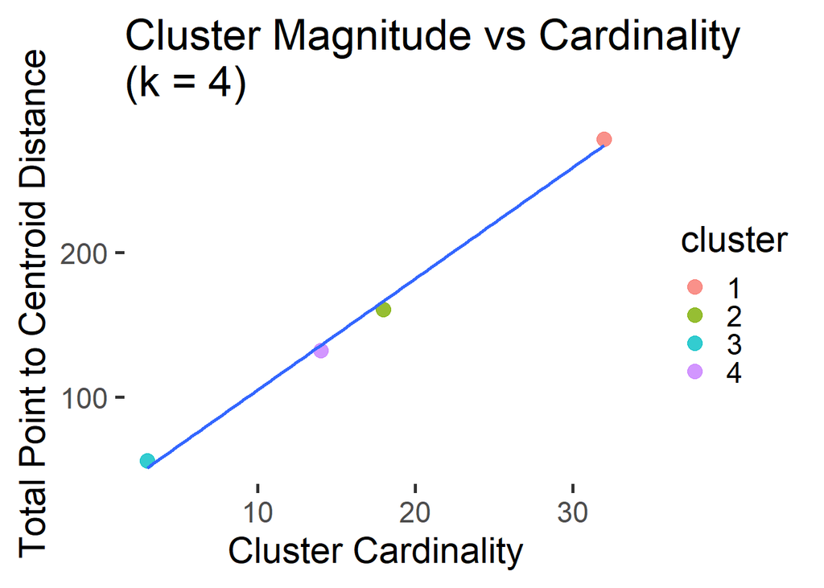

```r
k_4_dat <- cbind.data.frame(table(clusters_1), k_4_mag[,2]) # Join magnitude and cardinality

names(k_4_dat) <- c("cluster", "cardinality", "magnitude") # Fix plot data names

# Create scatter plot
g_6 <- ggplot(k_4_dat, aes(x = cardinality, y = magnitude, color = cluster)) + # Set aesthetics
  geom_point(alpha = 0.8, size  = 4) +  # Set geom point for scatter
 geom_smooth(aes(x = cardinality, y = magnitude), method = "lm",
              se = FALSE, inherit.aes = FALSE, alpha = 0.5) + # Set trend  line
  labs(x = "Cluster Cardinality", y="Total Point to Centroid Distance", # Set labels
         title = "Cluster Magnitude vs Cardinality \n(k = 4)") +
  theme(panel.grid.major = element_blank(), # Turn of the background grid
        panel.grid.minor = element_blank(),
        panel.border = element_blank(),
        panel.background = element_blank())


k_6_dat <- cbind.data.frame(table(clusters_2), k_6_mag[,2]) # Join magnitude and cardinality

names(k_6_dat) <- c("cluster", "cardinality", "magnitude") # Fix plot data names

# Create scatter plot
g_7 <- ggplot(k_6_dat, aes(x = cardinality, y = magnitude, color = cluster)) + # Set aesthetics
  geom_point(alpha = 0.8, size = 4) +  # Set geom point for scatter
  geom_smooth(aes(x = cardinality, y = magnitude), method = "lm",
              se = FALSE, inherit.aes = FALSE, alpha = 0.5) + # Set trend  line
  labs(x = "Cluster Cardinality", y="Total Point to Centroid Distance", # Set labels
         title = "Cluster Magnitude vs Cardinality \n(k = 6)") +
  theme(panel.grid.major = element_blank(), # Turn of the background grid
        panel.grid.minor = element_blank(),
        panel.border = element_blank(),
        panel.background = element_blank())

# Generate scatter plots
g_6
```

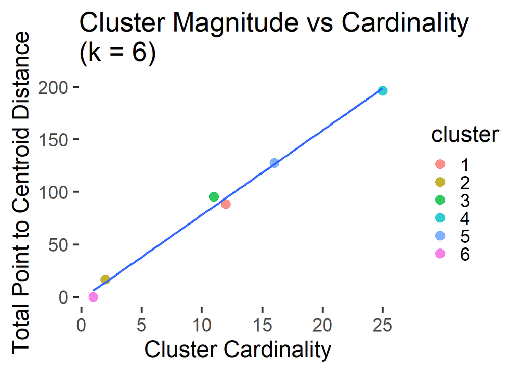

```r
g_7
```

If we find problems at this step we can take the following actions

- Scale data - Data already scaled
- Correct similarity measure - Will check in next step
- Check data operations are meaningful - Ask is k-means meaningful for this data
- Check the clustering algorithm assumptions match up to data

K-means makes two assumptions about the data:

1. The clusters are spherical in high dimensional space
2. The clusters are of equal size

While the first assumption is likely satisfied by this dataset, from our results we can see that the second assumption is likely violated. One method of proceeding here would be to drop the military academies from our analysis.

### Is the Similarity Measure Suitable

To check if we have chosen a suitable similarity measure we can analyse samples in the dataset that are known to be similar and dissimilar. We can calculate the similarity measures for these points and check that the similarity measure is quantifying the similarities between these points as expected.

```r
cat("Georgia v Michigan")
```

```
## Georgia v Michigan
```

```r
dist(off_dat[off_dat$teams %in% c("Georgia", "Michigan" ),2:20])[1]
```

```
## [1] 6.244021
```

```r
cat("Georgia v Notre Dame")
```

```
## Georgia v Notre Dame
```

```r
dist(off_dat[off_dat$teams %in% c("Georgia", "Notre Dame" ),2:20])[1]
```

```
## [1] 5.734377
```

```r
cat("Georgia v Army")
```

```
## Georgia v Army
```

```r
dist(off_dat[off_dat$teams %in% c("Georgia",  "Army"),2:20])[1]
```

```
## [1] 16.32075
```

```r
cat("Notre Dame v Army")
```

```
## Notre Dame v Army
```

```r
dist(off_dat[off_dat$teams %in% c("Notre Dame",  "Army"),2:20])[1]
```

```
## [1] 12.8674
```

```r
cat("Notre Dame v Stanford")
```

```
## Notre Dame v Stanford
```

```r
dist(off_dat[off_dat$teams %in% c("Notre Dame",  "Stanford"),2:20])[1]
```

```
## [1] 4.650009
```

These distances appear pretty close to what we would expect from the data, so we can conclude that our distance measure is working correctly. If these distances were not as expected we would need to reconsider the distance measure that we are using.

### Do we have the optimum number of clusters

A final thing to check is the number of clusters in our data. Here we have already taken advantage of the elbow method to evaluate the number of clusters in our dataset and visualized the structure of the clustering using the silhouette plot. Both are useful techniques for this area. The suggested diagnostic measures for checking the optimum number of clusters are:

- Check clustering of similar and dissimilar examples
- Plot error vs number of clusters to find optimum number of clusters - Elbow method

We can then check the clustering of our similar and dissimilar observations:

```r
# Join data and clustering solution for K=4 for select teams
k_4_sol <- cbind.data.frame(off_dat$teams[off_dat$teams %in% c("Michigan", "Army", "Georgia",
                                                               "Notre Dame", "Stanford")],
                            clusters_1[off_dat$teams %in% c("Michigan", "Army", "Georgia",
                                                               "Notre Dame", "Stanford")])
# Set names on new dataset
names(k_4_sol) <- c("team", "cluster")
cat("When K = 4:")
```

```
## When K = 4:
```

```r
print(k_4_sol) # Print results
```

```
##           team cluster
## 9      Georgia       2
## 27  Notre Dame       1
## 41    Michigan       4
## 116   Stanford       4
## 211       Army       3
```

```r
# Join data and clustering solution for K=6 for select teams
k_6_sol <- cbind.data.frame(off_dat$teams[off_dat$teams %in% c("Michigan", "Army", "Georgia",
                                                               "Notre Dame", "Stanford")],
                            clusters_2[off_dat$teams %in% c("Michigan", "Army", "Georgia",
                                                               "Notre Dame", "Stanford")])
# Set names on new dataset
names(k_6_sol) <- c("team", "cluster")
cat("When K = 6:")
```

```
## When K = 6:
```

```r
print(k_6_sol) # Print results
```

```
##           team cluster
## 9      Georgia       5
## 27  Notre Dame       4
## 41    Michigan       4
## 116   Stanford       1
## 211       Army       6
```

These look pretty good, however, it is interesting to note that Georgia and Notre Dame end up in different clusters for K=6 even though they are quite similar to each other. This may indicate that we have too many clusters in the data if we want Georgia and Notre Dame to be in the same cluster, or that there are too few if we expect Notre Dame and Georgia/Michigan to be in different clusters.

The remedies for this problem are:

- If similar examples are in different clusters then there may be too many clusters in the data
- If dissimilar examples are in the same cluster then there may be too few clusters
- Using the plot of cluster number vs error choose number of clusters where reduction in error begins to decrease

# Improving clustering:

Lets try clustering the data excluding the military academies:

```r
# Drop small cluster samples
off_dat_2 <- off_dat[!off_dat$teams %in% c("Army", "Air Force", "Navy"),]
```

Next visualize the number of clusters that is now optimum for the dataset:

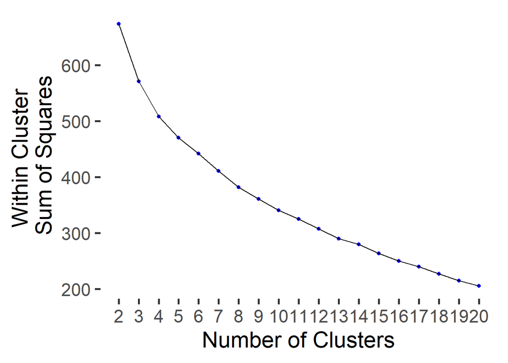

```r
# Create function to try different cluster numbers
kmean_withinss <- function(k) {
  cluster <- kmeans( x = off_dat_2[,2:20],  # Set data to use
                    centers = k,  # Set number of clusters as k, changes with input into function
                    nstart = 25, # Set number of starts
                    iter.max = 100) # Set max number of iterations
  return (cluster$tot.withinss) # Return cluster error/within cluster sum of squares
}


# Set maximum cluster number
max_k <-20
# Run algorithm over a range of cluster numbers
wss <- sapply(2:max_k, kmean_withinss)


# Create a data frame to plot the graph
elbow <-data.frame(2:max_k, wss)

# Plot the graph with gglop
g_8 <- ggplot(elbow, aes(x = X2.max_k, y = wss)) +
  theme_set(theme_bw(base_size = 22) ) +
  geom_point(color = "blue") +
  geom_line() +
  scale_x_continuous(breaks = seq(1, 20, by = 1)) +
  labs(x = "Number of Clusters", y="Within Cluster \nSum of Squares") +
  theme(panel.grid.major = element_blank(), # Turn of the background grid
        panel.grid.minor = element_blank(),
        panel.border = element_blank(),
        panel.background = element_blank())
g_8
```

Again this is pretty uninformative, lets try using some other methods for choosing cluster number. For these we can use:

1. Average silhouette width
2. The gap statistic

The average silhouette width uses the silhouette measure we have been using previously and uses the average width as a measure of error. The Gap statistic compares the inter cluster variation for different values of K with their expected values if there was no obvious clustering in the data. It works by generating random values for each variable, clustering them and then comparing the within cluster sum of squares to the clustering solution on the original data.

The gap statistic process is:

1. Cluster the data with different values of k, calculate the within cluster sum of squares
2. Generate B bootstrap datasets with random values for each observation, where the random values fall within the minimum and maximum values of the observed data. Compute the within cluster sum of squares.
3. Calculate deviation between random and observed data clusterings. (Gap Statistic)
4. Choose smallest k such that the gap statistic for k is less than 1 standard deviation from the highest gap statistic value.

We can plot the silhouette value for multiple different numbers of clusters using `fviz_nbclust()`:

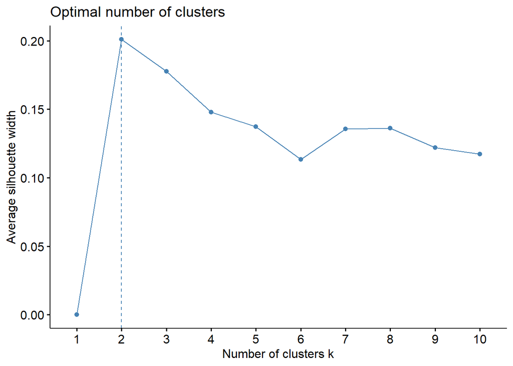

```r
# Create silhouette plot summary
fviz_nbclust(off_dat_2[,2:20], # Set dataset
             kmeans,# Set clustering method
             method = "silhouette") # Set evaluation method
```

To calculate the gap statistic we run the following:

```r
# compute gap statistic
set.seed(999999)
gap_stat <- clusGap(off_dat_2[,2:20], FUN = kmeans, nstart = 25,
                    K.max = 20, B = 50)
# Print the result
print(gap_stat, method = "firstmax")
```

```
## Clustering Gap statistic ["clusGap"] from call:
## clusGap(x = off_dat_2[, 2:20], FUNcluster = kmeans, K.max = 20,     B = 50, nstart = 25)
## B=50 simulated reference sets, k = 1..20; spaceH0="scaledPCA"
##  --> Number of clusters (method 'firstmax'): 1
##           logW   E.logW       gap     SE.sim
##  [1,] 4.381980 4.676099 0.2941194 0.03070164
##  [2,] 4.242740 4.510141 0.2674005 0.02579999
##  [3,] 4.158979 4.407280 0.2483008 0.02482571
##  [4,] 4.093736 4.334118 0.2403812 0.02174859
##  [5,] 4.045457 4.280070 0.2346135 0.02139948
##  [6,] 4.006860 4.231053 0.2241929 0.02171940
##  [7,] 3.964573 4.186690 0.2221165 0.02268825
##  [8,] 3.921362 4.145760 0.2243977 0.02249446
##  [9,] 3.883585 4.106948 0.2233635 0.02212260
## [10,] 3.846948 4.069170 0.2222215 0.02234745
## [11,] 3.810157 4.033525 0.2233676 0.02257039
## [12,] 3.776780 3.998484 0.2217045 0.02325458
## [13,] 3.743826 3.964049 0.2202237 0.02298491
## [14,] 3.702927 3.929740 0.2268130 0.02366418
## [15,] 3.671220 3.895481 0.2242609 0.02365817
## [16,] 3.634541 3.862983 0.2284427 0.02416695
## [17,] 3.598267 3.829863 0.2315956 0.02449498
## [18,] 3.563006 3.795914 0.2329080 0.02550959
## [19,] 3.527078 3.762410 0.2353313 0.02528092
## [20,] 3.489182 3.728675 0.2394926 0.02506293
```

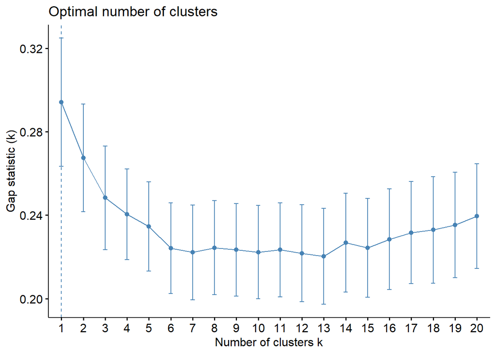

```r
# Visulaize Result
fviz_gap_stat(gap_stat)
```

From the gap statistic, we get an optimum number of clusters as 1, which does not work well for analysis. Often the choice of optimal cluster number is a combination of both statistical results and analysis requirements. We will proceed with k as 2, using the silhouette plot.

```r
set.seed(12345) # Set seed for reproducibility
fit_3 <- kmeans(x = off_dat_2[2:20], # Set data as explantory variables
                centers = 2,  # Set number of clusters
                nstart = 25, # Set number of starts
                iter.max = 100 ) # Set maximum number of iterations to use

# Extract clusters
clusters_3 <- fit_3$cluster
# Extract centers
centers_3 <- fit_3$centers

# Check samples per cluster
summary(as.factor(clusters_3))
```

```
##  1  2
## 27 37
```

Lets view the teams in each cluster:

```r
# Check teams in cluster 1
cat("Cluster 1 teams:\n")
```

```
## Cluster 1 teams:
```

```r
off_dat_2$teams[clusters_3 == 1]
```

```
##  [1] "Georgia"        "Clemson"        "Oklahoma"       "Texas"
##  [5] "USC"            "Minnesota"      "Maryland"       "Michigan State"
##  [9] "UCLA"           "Washington"     "Wake Forest"    "Duke"
## [13] "Virginia"       "Louisville"     "Purdue"         "Colorado"
## [17] "Oklahoma State" "NC State"       "TCU"            "Stanford"
## [21] "Syracuse"       "Pittsburgh"     "Florida State"  "Utah"
## [25] "Arizona"        "Texas Tech"     "Northwestern"
```

```r
# Check teams in cluster 2
cat("Cluster 2 teams:\n")
```

```
## Cluster 2 teams:
```

```r
off_dat_2$teams[clusters_3 == 2]
```

```
##  [1] "Alabama"           "Arkansas"          "Auburn"
##  [4] "Miami"             "Florida"           "Kentucky"
##  [7] "Ole Miss"          "Mississippi State" "Missouri"
## [10] "South Carolina"    "Tennessee"         "Notre Dame"
## [13] "Texas A&M"         "Virginia Tech"     "Vanderbilt"
## [16] "North Carolina"    "Indiana"           "Michigan"
## [19] "Nebraska"          "Ohio State"        "Oregon"
## [22] "Penn State"        "Rutgers"           "Wisconsin"
## [25] "Iowa State"        "BYU"               "Georgia Tech"
## [28] "Boston College"    "Louisiana"         "Kansas"
## [31] "Arizona State"     "Baylor"            "Kansas State"
## [34] "Washington State"  "New Mexico State"  "Oregon State"
## [37] "Illinois"
```

Lets look at the cluster centers and see how they compare:

```r
# Create cluster vector
cluster <- c(1:2)
# Join cluster vector and centers
center_df <- data.frame(cluster, centers_3)

# Reshape the data
center_reshape <- gather(center_df, features, values, Pass_freq_per_game:Rush_prop_per_game_third_down)
# View result
head(center_reshape)
```

```
##   cluster           features     values
## 1       1 Pass_freq_per_game  0.7137781
## 2       2 Pass_freq_per_game -0.2758494
## 3       1 Rush_freq_per_game -0.7865728
## 4       2 Rush_freq_per_game  0.3304764
## 5       1 Punt_freq_per_game  0.4129821
## 6       2 Punt_freq_per_game -0.2889662
```

```r
# Create plot
g_heat_2 <- ggplot(data = center_reshape, # Set dataset
                   aes(x = features, y = cluster, fill = values)) + # Set aesthetics
  scale_y_continuous(breaks = seq(1, 2, by = 1)) + # Set y axis breaks
  geom_tile() + # Set geom tile for heatmap
  coord_equal() +  # Set coord equal
  theme_bw() + # Set theme
  scale_fill_gradient2(low = "blue", # Choose low color
                       mid = "white", # Choose mid color
                       high = "red", # Choose high color
                       midpoint =0, # Choose mid point
                       space = "Lab",
                       na.value ="grey", # Choose NA value
                       guide = "colourbar", # Set color bar
                       aesthetics = "fill") + # Select aesthetics to apply
  coord_flip() # Rotate plot
```

[output not shown]

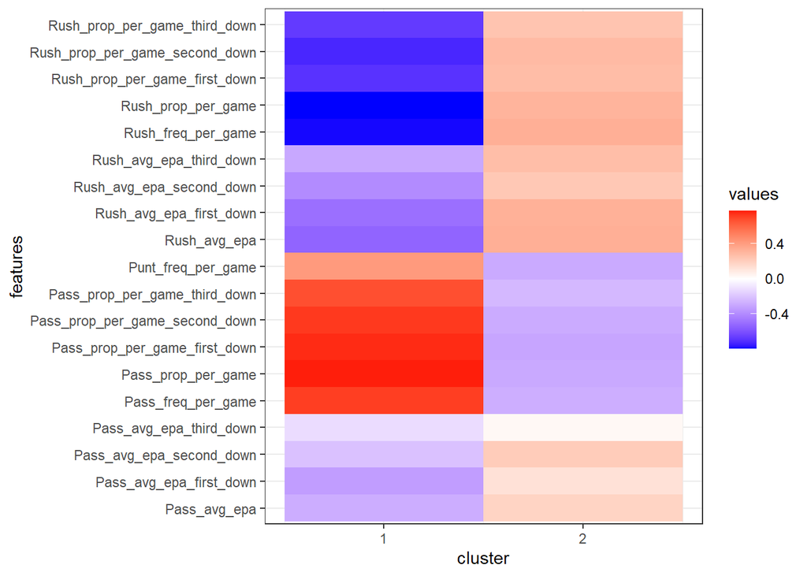

```r
# Generate plot
g_heat_2
```

# Sparse Clustering

```r
# Run sparse k-means permute to calculate optimal number of varaibles
km.perm <- KMeansSparseCluster.permute(x = off_dat_2[2:20], # Set data
                                       K=2, # Set cluster number
                                       nperms=5) # Set number of permuations
```

```
## 10122013014012501234560127012801239011001
## Permutation  1 of  5
## 10122013014015016017018019011001
## Permutation  2 of  5
## 10122013014015016017018019011001
## Permutation  3 of  5
## 101232013014015016017018019011001
## Permutation  4 of  5
## 1012320130124015016017018019011001
## Permutation  5 of  5
## 10122013014015016017018019011001
```

```r
# Print result
print(km.perm)
```

```
## Tuning parameter selection results for Sparse K-means Clustering:
##    Wbound # Non-Zero W's Gap Statistic Standard Deviation
## 1  1.2000              5       -0.3484             0.0874
## 2  1.3688              5       -0.2526             0.0844
## 3  1.5614              5       -0.1539             0.0828
## 4  1.7810              5       -0.0499             0.0827
## 5  2.0315              6        0.1091             0.0827
## 6  2.3173              8        0.1887             0.0827
## 7  2.6433             10        0.2821             0.0827
## 8  3.0151             10        0.3965             0.0827
## 9  3.4392             19        0.4243             0.0827
## 10 3.9230             19        0.4243             0.0827
## Tuning parameter that leads to largest Gap statistic:  3.439217
```

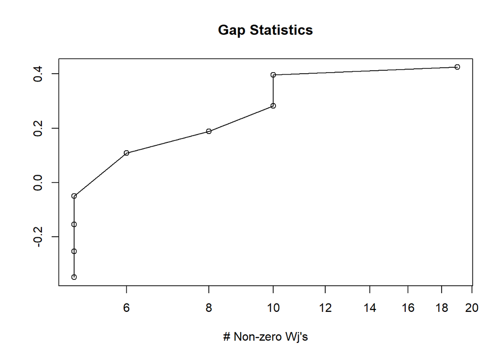

```r
# Visualise result
plot(km.perm)
```

```r
# Run sparse K-means with selected value of tuning parameter
km.sparse <- KMeansSparseCluster(x = off_dat_2[2:20], # Set data
                                 K=2, # Set cluster number
                                 wbounds =  2.03151, # Set tuning parameter
                                 nstart = 25, # Set number of starts
                                 maxiter=100) # Set number of iterations
```

```
## 01234
```

We can then extract the cluster and weights for the center values as follows:

```r
clusters_4 <- km.sparse[[1]]$Cs # Extract clusters

centers_4 <- km.sparse[[1]]$ws # Extract weights
```

We can then view the center weights as follows:

```r
# View weights
centers_4
```

```
##             Pass_freq_per_game             Rush_freq_per_game
##                     0.21012615                     0.07159711
##             Punt_freq_per_game                   Pass_avg_epa
##                     0.00000000                     0.00000000
##                   Rush_avg_epa             Pass_prop_per_game
##                     0.00000000                     0.20434960
##             Rush_prop_per_game        Pass_avg_epa_first_down
##                     0.24171236                     0.00000000
##        Rush_avg_epa_first_down  Pass_prop_per_game_first_down
##                     0.00000000                     0.66989030
##  Rush_prop_per_game_first_down       Pass_avg_epa_second_down
##                     0.63386452                     0.00000000
##       Rush_avg_epa_second_down Pass_prop_per_game_second_down
##                     0.00000000                     0.00000000
## Rush_prop_per_game_second_down        Pass_avg_epa_third_down
##                     0.00000000                     0.00000000
##        Rush_avg_epa_third_down  Pass_prop_per_game_third_down
##                     0.00000000                     0.00000000
##  Rush_prop_per_game_third_down
##                     0.00000000
```

# Exercises

For this analysis we are going analyse patterns of customer behavior and see if we can find groups that exhibit similar patterns of consumer behavior. We will then analyse the churn rate for each of these subgroups.

The dataset we are going to be using contains customer level information for a telecoms company with various attributes related to usage collected.

With the rapid development of telecommunication industry, the service providers are inclined more towards expansion of the subscriber base. To meet the need of surviving in the competitive environment, the retention of existing customers has become a huge challenge. It is stated that the cost of acquiring a new customer is far more than that for retaining the existing one. Therefore, it is imperative for the telecom industries to use advanced analytics to understand consumer behavior and in-turn predict the association of the customers as whether or not they will leave the company.

Let’s load the data into the workspace. The data is stored as `telecom_churn.rda`.

```r
load("telecom_churn.rda")
```

Let’s view the data:

```r
head(telecom_churn) # View first few rows of telecom dataset
```

```
##   Churn AccountWeeks ContractRenewal DataPlan DataUsage CustServCalls DayMins
## 1     0          128               1        1       2.7             1   265.1
## 2     0          107               1        1       3.7             1   161.6
## 3     0          137               1        0       0.0             0   243.4
## 4     0           84               0        0       0.0             2   299.4
## 5     0           75               0        0       0.0             3   166.7
## 6     0          118               0        0       0.0             0   223.4
##   DayCalls MonthlyCharge OverageFee RoamMins
## 1      110            89       9.87     10.0
## 2      123            82       9.78     13.7
## 3      114            52       6.06     12.2
## 4       71            57       3.10      6.6
## 5      113            41       7.42     10.1
## 6       98            57      11.03      6.3
```

```r
tail(telecom_churn) # View last few rows of telecom dataset
```

```
##      Churn AccountWeeks ContractRenewal DataPlan DataUsage CustServCalls
## 3328     0           79               1        0      0.00             2
## 3329     0          192               1        1      2.67             2
## 3330     0           68               1        0      0.34             3
## 3331     0           28               1        0      0.00             2
## 3332     0          184               0        0      0.00             2
## 3333     0           74               1        1      3.70             0
##      DayMins DayCalls MonthlyCharge OverageFee RoamMins
## 3328   134.7       98          40.0       9.49     11.8
## 3329   156.2       77          71.7      10.78      9.9
## 3330   231.1       57          56.4       7.67      9.6
## 3331   180.8      109          56.0      14.44     14.1
## 3332   213.8      105          50.0       7.98      5.0
## 3333   234.4      113         100.0      13.30     13.7
```

```r
dim(telecom_churn) # Check dimensions of telecom dataset
```

```
## [1] 3333   11
```

We see that we have 3,333 observations for 11 variables in the dataset. The variables we have are:

- Churn - 1 if customer cancelled service, 0 if not
- AccountWeeks - Number of weeks the customer has had an active account
- ContractRenewal - 1 if customer recently renewed contract, 0 if not
- DataPlan - 1 if customer has data plan, 0 if not
- DataUsage - Gigabytes of monthly data usage
- CustServCalls - Number of calls to customer service
- DayMins - Average number of day time minutes
- DayCalls - Average number of daytime calls
- MonthlyCharge - Average monthly charge
- OverageFee - Largest overage free in the last 12 months
- RoamMins - Average number of roaming minutes

When clustering we will exclude the churn variable and then analyse clusters by their churn rate.

We can view a summary of this data by running `summary()`:

```r
summary(telecom_churn)
```

```
##      Churn         AccountWeeks   ContractRenewal     DataPlan
##  Min.   :0.0000   Min.   :  1.0   Min.   :0.0000   Min.   :0.0000
##  1st Qu.:0.0000   1st Qu.: 74.0   1st Qu.:1.0000   1st Qu.:0.0000
##  Median :0.0000   Median :101.0   Median :1.0000   Median :0.0000
##  Mean   :0.1449   Mean   :101.1   Mean   :0.9031   Mean   :0.2766
##  3rd Qu.:0.0000   3rd Qu.:127.0   3rd Qu.:1.0000   3rd Qu.:1.0000
##  Max.   :1.0000   Max.   :243.0   Max.   :1.0000   Max.   :1.0000
##    DataUsage      CustServCalls      DayMins         DayCalls
##  Min.   :0.0000   Min.   :0.000   Min.   :  0.0   Min.   :  0.0
##  1st Qu.:0.0000   1st Qu.:1.000   1st Qu.:143.7   1st Qu.: 87.0
##  Median :0.0000   Median :1.000   Median :179.4   Median :101.0
##  Mean   :0.8165   Mean   :1.563   Mean   :179.8   Mean   :100.4
##  3rd Qu.:1.7800   3rd Qu.:2.000   3rd Qu.:216.4   3rd Qu.:114.0
##  Max.   :5.4000   Max.   :9.000   Max.   :350.8   Max.   :165.0
##  MonthlyCharge      OverageFee       RoamMins
##  Min.   : 14.00   Min.   : 0.00   Min.   : 0.00
##  1st Qu.: 45.00   1st Qu.: 8.33   1st Qu.: 8.50
##  Median : 53.50   Median :10.07   Median :10.30
##  Mean   : 56.31   Mean   :10.05   Mean   :10.24
##  3rd Qu.: 66.20   3rd Qu.:11.77   3rd Qu.:12.10
##  Max.   :111.30   Max.   :18.19   Max.   :20.00
```

Please complete the following exercises:

- 1 - Scale the dataset (Exclude the churn variable)
- 2 - Choose optimal cluster number for the dataset (May not be clear)
- 3 - Apply K-means clustering with optimal number of clusters
- 4 - View number of samples in each cluster
- 5 - View churn rate for each cluster (Hint: `mean(telecom_churn$Churn[clusters_1 == 1])` )
- 6 - Visualize centers of each cluster
- 7 - What are the features of each cluster and which variables are likely related to churn